# Programming

“8. Data Visualization I”

“Wen-Bin Chuang”

“2024/07/25”

# Today’s Topics

- Introduction of Mathplotlib
- Layout
- Matplotlib Gallery
- Figure and Axes

# Introduction

Data visualization is a key skill for aspiring data scientists. They creates meaningful and insightful plots. We’ll learn how to build various types of plots, and customize them to be more visually appealing and interpretable.

# ** Matplotlib**

```python
# python -m pip install --user matplotlib # via `the command line (cmd) `
pip install matplotlib
print(plt.__version__)
```

```python
import matplotlib.pyplot as plt
import numpy as np
import pandas as pd
import seaborn as sns

%matplotlib inline
sns.set()
```

The command “%matplotlib inline” makes only sense, if you work with “Ipython Notebook such as colab”.

# 1. Matplotlib Plotting

By default, the “plot()” function draws a **line from point to point.** The function takes parameters for specifying points in the diagram. Parameter 1 is an array containing the points on the **x-axis**. Parameter 2 is an array containing the points on the **y-axis**.

```python
x = np.array([1, 8])
y = np.array([3, 10])

plt.plot(x, y)
plt.show()
```

```python
# Without Line
plt.plot(x, y, 'o')
plt.show()

# Default X-Points
plt.plot(y)
plt.show()
```

## 1.1.1 Markers

The keyword argument **marker** to emphasize each point with a specified marker

```python
y = np.array([3, 8, 1, 10])

plt.plot(y, marker = 'o')
plt.show()

plt.plot(y, marker = '*')
plt.show()
```

| Marker | Description |
| --- | --- |
| ‘o’ | Circle |
| ’*’ | Star |
| ‘.’ | Point |
| ‘,’ | Pixel |
| ‘x’ | X |
| ‘X’ | X (filled) |
| ‘+’ | Plus |
| ‘P’ | Plus (filled) |
| ‘s’ | Square |
| ‘D’ | Diamond |
| ‘d’ | Diamond (thin) |
| ‘p’ | Pentagon |
| ‘H’ | Hexagon |
| ‘h’ | Hexagon |
| ‘v’ | Triangle Down |
| ‘^’ | Triangle Up |
| ‘<’ | Triangle Left |
| ‘>’ | Triangle Right |
| ‘1’ | Tri Down |
| ‘2’ | Tri Up |
| ‘3’ | Tri Left |
| ‘4’ | Tri Right |
| ‘\|’ | Vline |
| ’_’ | Hline |

| Line Syntax | Description |
| --- | --- |
| ‘-’ | Solid line |
| ‘:’ | Dotted line |
| ‘–’ | Dashed line |
| ‘-.’ | Dashed/dotted line |

## **1.1.2 Marker Size and Color

```python
y = np.array([3, 8, 1, 10])

# `ms` to set the size of the markers
plt.plot(y, marker = 'o', ms = 20)
plt.show()

# `mec` to set the color of the *edge* of the markers

plt.plot(y, marker = 'o', ms = 20, mec = 'r')
plt.show()
```

# **1.2 Matplotlib Line**

```python
y = np.array([3, 8, 1, 10])

plt.plot(y, linestyle = 'dotted') # 'dashed'
plt.show()
```

## 1.2.1 Multiple Lines

```python
y1 = np.array([3, 8, 1, 10])
y2 = np.array([6, 2, 7, 11])

plt.plot(y1)
plt.plot(y2)

plt.show()
```

# 2. Layout

## 2.1 Labels and Title

we can use the “xlabel()” and “ylabel()” functions to set a label for the x- and y-axis. The “title()” function to set a title for the plot

```python
x = np.array([80, 85, 90, 95, 100, 105, 110, 115, 120, 125])
y = np.array([240, 250, 260, 270, 280, 290, 300, 310, 320, 330])

plt.plot(x, y)

plt.title("Sports Watch Data")
plt.xlabel("Average Pulse")
plt.ylabel("Calorie Burnage")

plt.show()
```

## 2.2 Legend

add an **explanation** for each wedge, use the “legend()” function

```python
x = np.array([80, 85, 90, 95, 100, 105, 110, 115, 120, 125])
y = np.array([240, 250, 260, 270, 280, 290, 300, 310, 320, 330])

plt.plot(x, y)

plt.title("Sports Watch Data")
plt.xlabel("Average Pulse")
plt.ylabel("Calorie Burnage")

plt.legend()
plt.show()
```

# 3. The type of Plots

## 3.1 Scatter - `plt.scatter()`

```python
x = np.array([5,7,8,7,2,17,2,9,4,11,12,9,6])
y = np.array([99,86,87,88,111,86,103,87,94,78,77,85,86])

plt.scatter(x, y, color = '#88c999')
plt.show()
```

## 3.2 Bars - `plt.bar()`

```python
x = np.array(["A", "B", "C", "D"])
y = np.array([3, 8, 1, 10])

plt.bar(x,y)
plt.show()
```

```python
# Horizontal Bars- `plt.barh()`
plt.barh(x, y)
plt.show()
```

## 3.3 Histograms - `plt.hist()`

```python
x = np.random.normal(170, 10, 250)

plt.hist(x)
plt.show()
```

## 3.4 Pie Charts - `plt.pie()`

```python
y = np.array([35, 25, 25, 15])
mylabels = ["Apples", "Bananas", "Cherries", "Dates"]

plt.pie(y, labels = mylabels, startangle = 90)
plt.show()
```

```python
y = np.array([35, 25, 25, 15])
mylabels = ["Apples", "Bananas", "Cherries", "Dates"]
myexplode = [0.2, 0, 0, 0]

plt.pie(y, labels = mylabels, explode = myexplode)
plt.show()
```

# 4.Ax.plot()

## 4.1 Figure and Axes

A matplotlib object is a tree-like structure of matplotlib objects which build a “hierarchy”. The top of the tree-like structure of matplotlib objects is the `figure` object. A figure can be seen as the container which contains one or more plots. The plots are called `axes` in matplotlib jargon. Axes is the plural of the word “axis”, which gives us a misleading idea. We can think about “axes” as a synonym for the word “plot”.

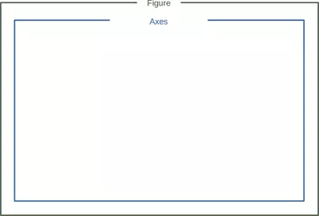

A figure may also contain more than one axes

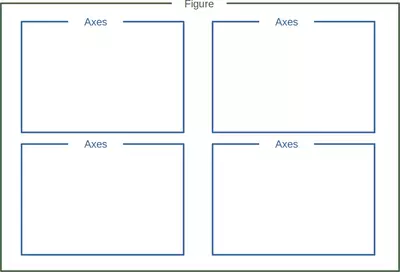

## 4.2 Subplot() and Subplots()

```python
import matplotlib.pyplot as plt
x = [1,2,3,4,5]
y = [5,4,3,2,1]

# subplot"s"
fig, (ax1, ax2) = plt.subplots(1, 2) # 1*2
ax1.plot(x)
ax2.plot(y)
plt.show()

# or
fig, ax = plt.subplots(2) # 2*1
ax[0].plot(x)
ax[1].plot(y)
plt.show()
```

```python
fig = plt.figure()
ax1 = plt.subplot(121)
ax1.plot(x)
ax2 = plt.subplot(122)
ax2.plot(y)

# or built-in method of fig
fig = plt.figure()
fig.add_subplot(121)
plt.plot(x)

fig.add_subplot(122)
plt.plot(y)
plt.show()
```

# 4.3 Basic Figure and Ax

```python
# layout
fig, (ax1, ax2, ax3) = plt.subplots(1, 3) # 1*3

# data
data=np.random.randn(50,).cumsum()

# ax.plot() - line
ax1.plot(data, 'k--', drawstyle='steps-post', label='Stepwise')
ax1.set_title('First Graph')
ax2.plot(data, "r-", drawstyle='steps-post', label='Stepwise')
ax2.set_title('First Graph')
ax3.plot(data, "b.", drawstyle='steps-post', label='Stepwise')
ax3.set_title('First Graph')

ax2.legend(loc='best')
plt.show()
```